# test_user_introduction

## Tab 1: the source population

**An appraisal starts with a place.**

- Select a Local Authority District (LAD), such as Leeds.
- The app draws on a synthetic population: people with linked travel and physical-activity information.
- Local patterns provide starting values for your appraisal.
- Your assessed population can be smaller than the whole district.

## Tab 2: active-travel volume

**Describe travel in the reference and intervention scenarios.**

1. **Users:** number of people using each mode.
2. **Trips:** number of trips, with a timeframe.
3. **Distance or duration:** travel distance or time.
4. **Mode shares:** percentages, with a total travel amount.

Initial values come from the source population. Edit these to describe your scheme.

## Tab 3: the assessed population

**First set the scope, then refine the distribution.**

- **Scope:** adjust REF and CF counts and eligible population categories.
- **Distribution:** refine age, sex and physical-activity patterns.
- Scope supplies count targets and filter criteria.
- Sampling weights favour particular people within the eligible pool.

Starting values come from Tab 2.

## Tab 4: trips and physical activity

**First set trip scope, then refine trip patterns.**

- **Scope:** adjust REF and CF trip totals. Keep population fixed.
- **Distribution:** refine distances and source modes for shifts.
- Scope supplies counts and filters. Distributions guide weights.
- Separately, specify the share of newly induced trips.

Changed travel time changes physical activity.

## Source population, REF and CF

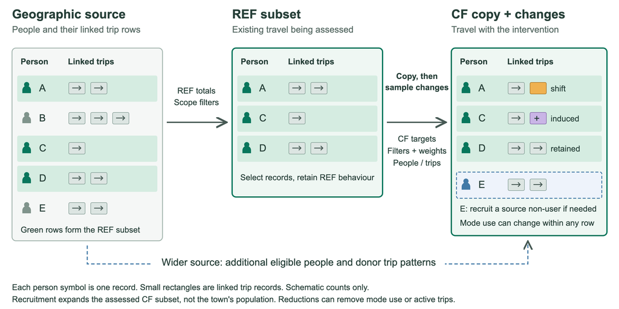

## Sampling: priorities and fallbacks

**CF starts from REF. The requested difference drives sampling.**

- **Priority:** explicit counts prevail. Tab 4 preserves Tab 3 people.
- **People:** eligible REF non-users first, then the wider source.
- **Trips:** shifts plus induced trips. Each trip can shift once.
- **Fallbacks:** relax weights, reuse trip patterns, or add induced trips when shifts fall short.

Filters remain binding. Too few eligible people requires a revised request.

## Tab 5: health impacts

**Activity changes affect modelled health outcomes.**

- Calculate the outcome difference: **CF minus REF**.
- Lower disease and mortality outcomes indicate a benefit.
- Report prevented deaths and disease cases, life-years gained and health-adjusted life-years (HALYs).
- Inspect plots and exports over the assessment period.

Results depend on the input estimates, source data and modelling assumptions.

## Backup: user-count inputs

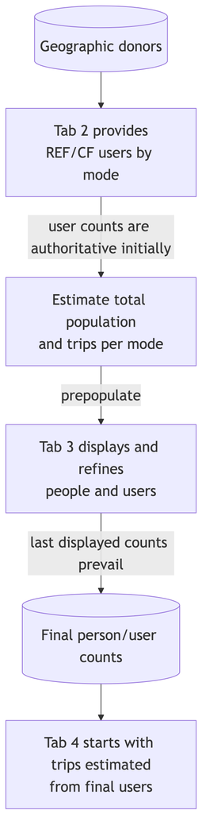

## Backup: trip-count inputs

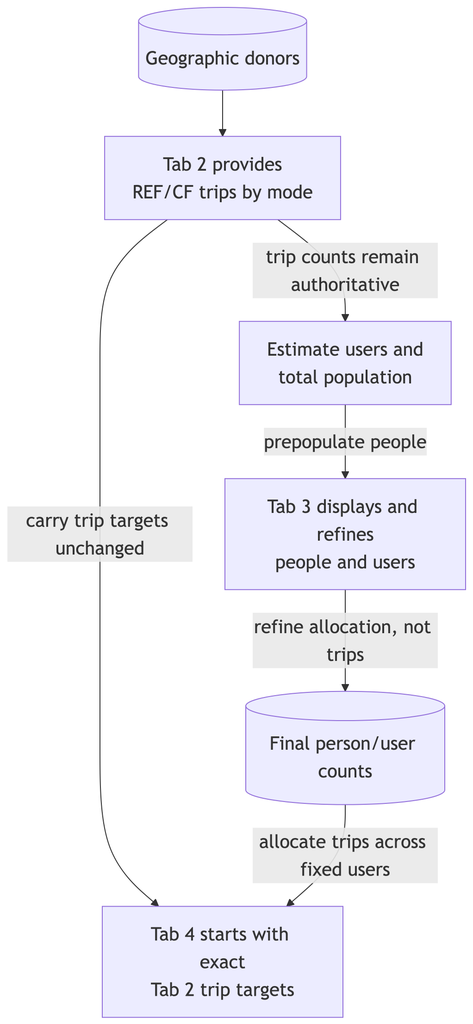

## Backup: distance or duration inputs

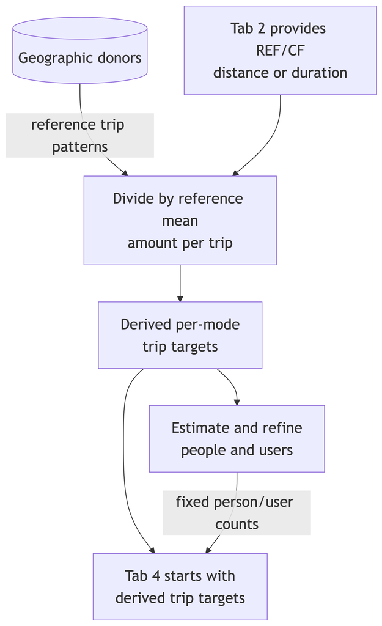

## Backup: mode-share inputs

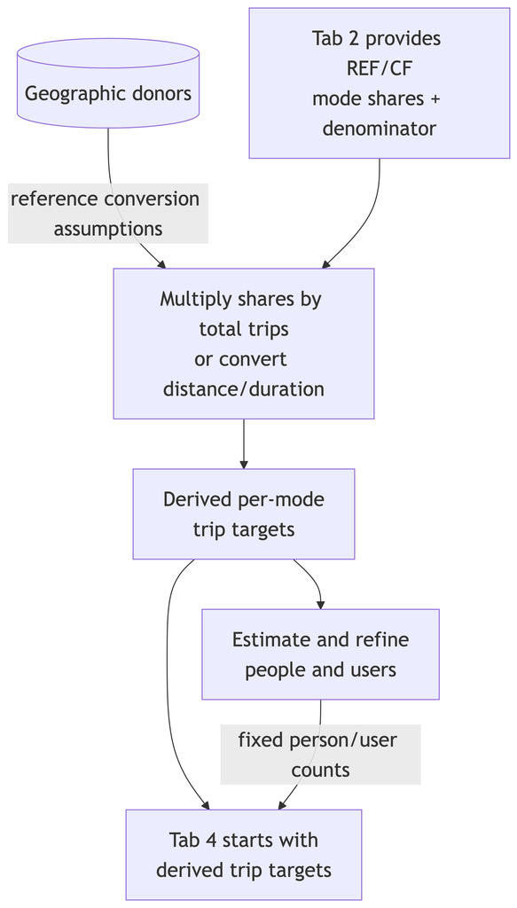

## Backup: population-to-results handoff

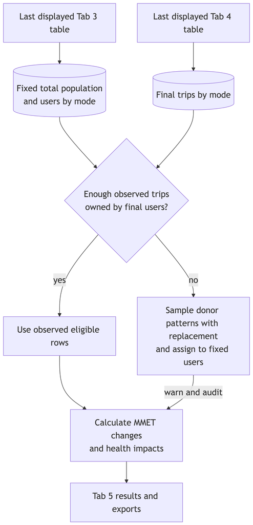

## Backup: complete workflow

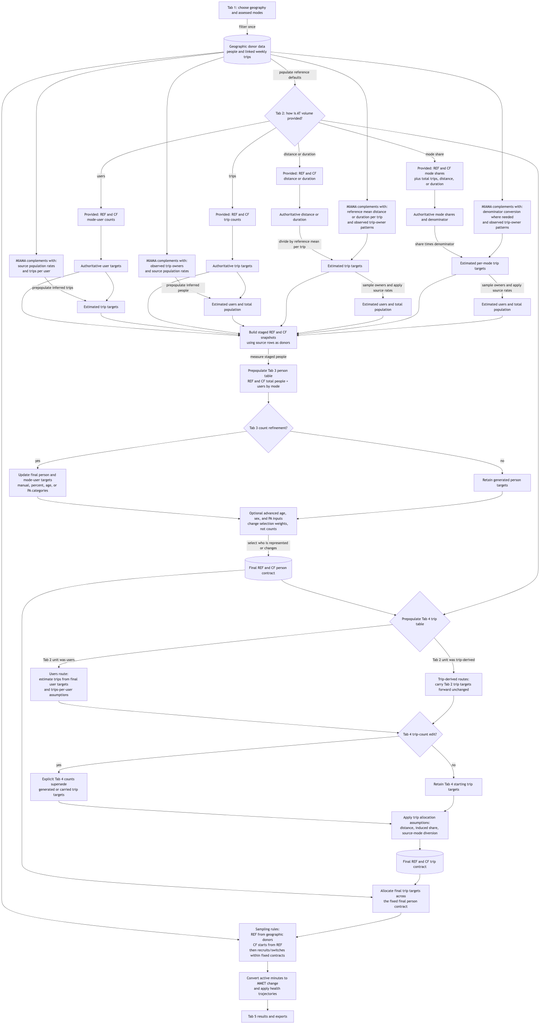